# Project 1 Asuransi Umum dan Kerugian

Maulida Nur Shabrina

[output not shown]

Question 1

Briefly discuss the data found (e.g., how many tariff cells, how many rating factors, what are the levels for each, how is the exposure determined).

Answer: a. There are 4 rating factors, including: zone, vehicle, age, and bonus b. Levels: - zone : 4 level - vehicle: 3 level - age : 4 level - bonus : 3 level c. Tarrif cells : (4)(3)(4)(3) = 144, there are 144 tarrif cells d. Exposure: duration as frequency and nbclaim as severity.

Rcode:

```r
library(foreach)
library(ggplot2)
library(MASS)
library(dplyr)
library(tinytex)
library(rmarkdown)
```

## Import data

```r
data = read.delim("autoinsurance.csv", sep=",")
head(data)
```

|  | zone | vehicle | age | bonus | duration | nbclaim | totalclaim |
| --- | --- | --- | --- | --- | --- | --- | --- |
| 1 | 1 | 1 | 1 | 1 | 34.580820 | 2 | 75367 |
| 2 | 1 | 1 | 1 | 2 | 14.419177 | 2 | 165000 |
| 3 | 1 | 1 | 1 | 3 | 8.843836 | 1 | 10000 |
| 4 | 1 | 1 | 2 | 1 | 41.769864 | 1 | 11000 |
| 5 | 1 | 1 | 2 | 2 | 30.139726 | 3 | 147723 |
| 6 | 1 | 1 | 2 | 3 | 75.999998 | 4 | 272588 |

```r
summary(data)
```

```
##       zone         vehicle       age           bonus      duration
##  Min.   :1.00   Min.   :1   Min.   :1.00   Min.   :1   Min.   :    1.888
##  1st Qu.:1.75   1st Qu.:1   1st Qu.:1.75   1st Qu.:1   1st Qu.:   28.955
##  Median :2.50   Median :2   Median :2.50   Median :2   Median :   82.555
##  Mean   :2.50   Mean   :2   Mean   :2.50   Mean   :2   Mean   :  398.954
##  3rd Qu.:3.25   3rd Qu.:3   3rd Qu.:3.25   3rd Qu.:3   3rd Qu.:  339.295
##  Max.   :4.00   Max.   :3   Max.   :4.00   Max.   :3   Max.   :10524.792
##     nbclaim         totalclaim
##  Min.   : 0.000   Min.   :     0
##  1st Qu.: 1.000   1st Qu.:  1340
##  Median : 2.000   Median : 25284
##  Mean   : 3.507   Mean   : 79147
##  3rd Qu.: 4.000   3rd Qu.: 87338
##  Max.   :41.000   Max.   :653862
```

## Converting predictor variables into categorical variables

```r
data <- within(data, {
  zone <- factor(zone)
  vehicle <- factor(vehicle)
  age <- factor(age)
  bonus <- factor(bonus)
})
summary(data)
```

```
##  zone   vehicle age    bonus     duration            nbclaim
##  1:36   1:48    1:36   1:48   Min.   :    1.888   Min.   : 0.000
##  2:36   2:48    2:36   2:48   1st Qu.:   28.955   1st Qu.: 1.000
##  3:36   3:48    3:36   3:48   Median :   82.555   Median : 2.000
##  4:36           4:36          Mean   :  398.954   Mean   : 3.507
##                               3rd Qu.:  339.295   3rd Qu.: 4.000
##                               Max.   :10524.792   Max.   :41.000
##    totalclaim
##  Min.   :     0
##  1st Qu.:  1340
##  Median : 25284
##  Mean   : 79147
##  3rd Qu.: 87338
##  Max.   :653862
```

## Calculating the outcomes/categories that differ for each predictor

```r
levels(data$zone)
```

```
## [1] "1" "2" "3" "4"
```

```r
levels(data$vehicle)
```

```
## [1] "1" "2" "3"
```

```r
levels(data$age)
```

```
## [1] "1" "2" "3" "4"
```

```r
levels(data$bonus)
```

```
## [1] "1" "2" "3"
```

From the level function, it is known that the predictors zone and age have 4 different categories, while vehicle and bonus have 3 categories each.

## Tariff Cells

```r
length(levels(data$zone))*length(levels(data$vehicle))*length(levels(data$age))*length(levels(data$bonus))
```

```
## [1] 144
```

There are 144 Tariff cells

## Defining frequency and severity

```r
# defining frequency
frequency = data$nbclaim/data$duration
head(frequency)
```

```
## [1] 0.05783553 0.13870417 0.11307311 0.02394071 0.09953641 0.05263158
```

```r
# defining severity
n = 144
severity = 0
for(i in 1:n){
  if(data$nbclaim[i] == 0){severity[i] = 0}
  else{severity[i] = data$totalclaim[i]/ data$nbclaim[i]}
}
head(severity)
```

```
## [1] 37683.5 82500.0 10000.0 11000.0 49241.0 68147.0
```

```r
# Combining frequency and severity into one dataframe
data2 <- cbind(data,frequency, severity)
head(data2)
```

|  | zone | vehicle | age | bonus | duration | nbclaim | totalclaim | frequency | severity |
| --- | --- | --- | --- | --- | --- | --- | --- | --- | --- |
| 1 | 1 | 1 | 1 | 1 | 34.580820 | 2 | 75367 | 0.05783553 | 37683.5 |
| 2 | 1 | 1 | 1 | 2 | 14.419177 | 2 | 165000 | 0.13870417 | 82500.0 |
| 3 | 1 | 1 | 1 | 3 | 8.843836 | 1 | 10000 | 0.11307311 | 10000.0 |
| 4 | 1 | 1 | 2 | 1 | 41.769864 | 1 | 11000 | 0.02394071 | 11000.0 |
| 5 | 1 | 1 | 2 | 2 | 30.139726 | 3 | 147723 | 0.09953641 | 49241.0 |
| 6 | 1 | 1 | 2 | 3 | 75.999998 | 4 | 272588 | 0.05263158 | 68147.0 |

Question 2

Answer: Based on the tariff cell with the largest exposure, the tariff cell (3, 3, 4, 3) is designated as the base tariff cell. Additionally, it can be observed that nearly all rating vectors have a p-value < alpha = 0.05, indicating that the rating vectors are significant to the model.

However, for the rating vectors zone4 and bonus2, the p-value is > alpha = 0.05, indicating that the rating vectors zone4 and bonus2 are not significant to the model.

It can also be noted that the scaled deviance is 132.1301, which is less than the critical value of 160.9148. The same result can also be seen from the p-value of 0.505003 > alpha = 0.05. Thus, it can be concluded that the frequency fitting model with relative Poisson provides good results.

Rcode: ## To better understand the relationship between predictors and claim frequency

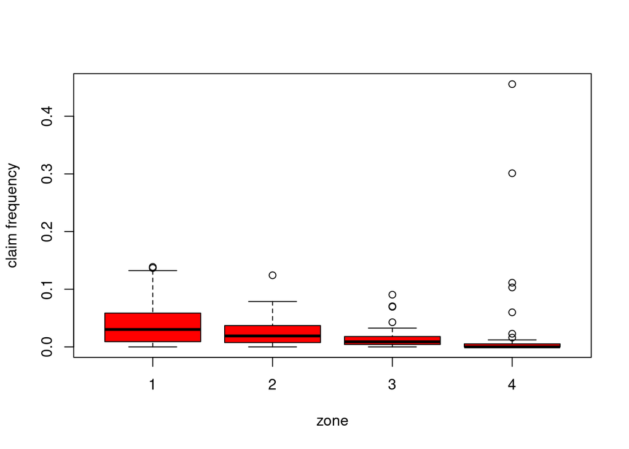

```r
# frequency vs zone
plot(data2$zone, data2$frequency, col="red",xlab="zone",ylab="claim frequency")
```

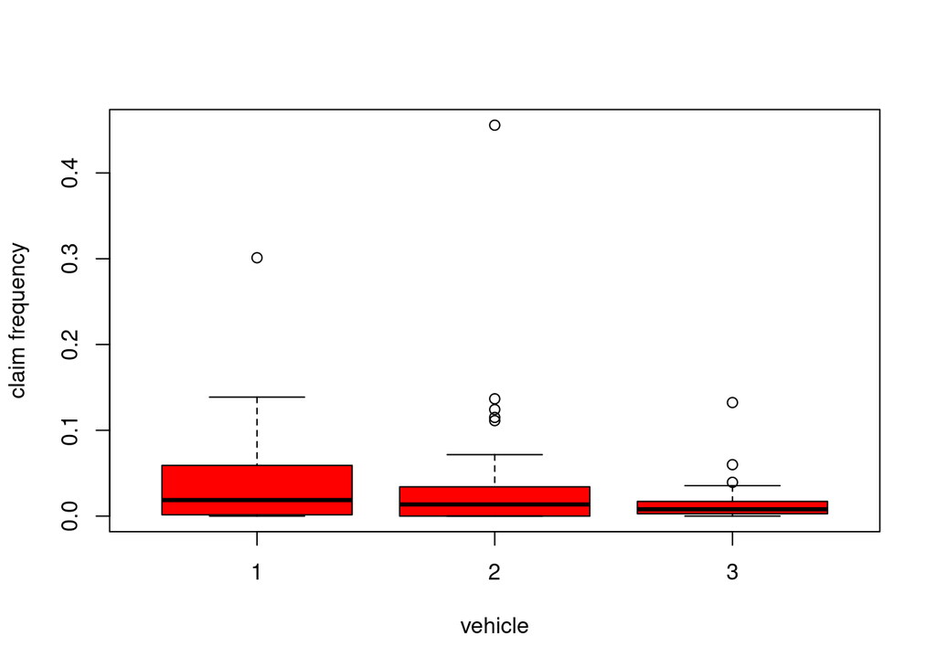

```r
# frequency vs vehicle
plot(data2$vehicle, data2$frequency, col="red",xlab="vehicle",ylab="claim frequency")
```

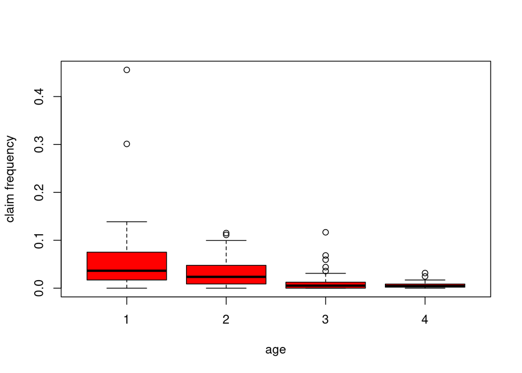

```r
# frequency vs age
plot(data2$age, data2$frequency, col="red",xlab="age",ylab="claim frequency")
```

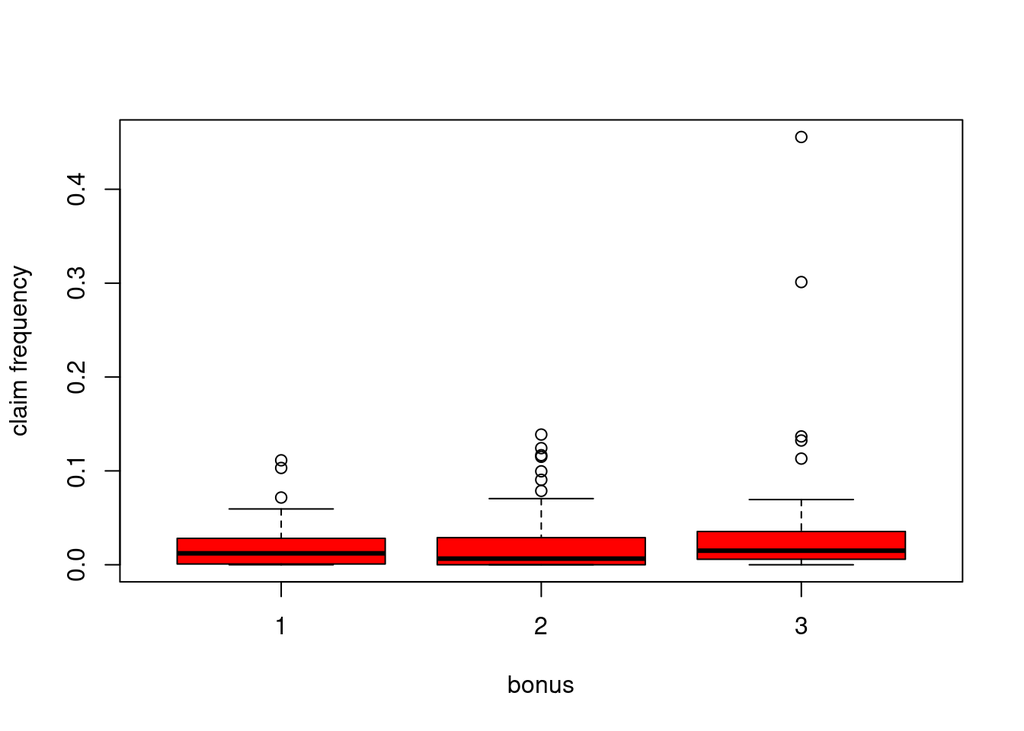

```r
# frequency vs bonus
plot(data2$bonus, data2$frequency, col="red", xlab="bonus", ylab="claim frequency")
```

## GLM Fitting

```r
# Setting the maximum exposure as the base tariff.
print(basecell<- data2[which.max(data2$duration), 1:4 ])
```

```
##     zone vehicle age bonus
## 108    3       3   4     3
```

```r
print(data2$zone<- relevel(data2$zone, as.character(basecell$zone)))
```

```
##   [1] 1 1 1 1 1 1 1 1 1 1 1 1 1 1 1 1 1 1 1 1 1 1 1 1 1 1 1 1 1 1 1 1 1 1 1 1 2
##  [38] 2 2 2 2 2 2 2 2 2 2 2 2 2 2 2 2 2 2 2 2 2 2 2 2 2 2 2 2 2 2 2 2 2 2 2 3 3
##  [75] 3 3 3 3 3 3 3 3 3 3 3 3 3 3 3 3 3 3 3 3 3 3 3 3 3 3 3 3 3 3 3 3 3 3 4 4 4
## [112] 4 4 4 4 4 4 4 4 4 4 4 4 4 4 4 4 4 4 4 4 4 4 4 4 4 4 4 4 4 4 4 4 4
## Levels: 3 1 2 4
```

```r
print(data2$vehicle<- relevel(data2$vehicle, as.character(basecell$vehicle)))
```

```
##   [1] 1 1 1 1 1 1 1 1 1 1 1 1 2 2 2 2 2 2 2 2 2 2 2 2 3 3 3 3 3 3 3 3 3 3 3 3 1
##  [38] 1 1 1 1 1 1 1 1 1 1 1 2 2 2 2 2 2 2 2 2 2 2 2 3 3 3 3 3 3 3 3 3 3 3 3 1 1
##  [75] 1 1 1 1 1 1 1 1 1 1 2 2 2 2 2 2 2 2 2 2 2 2 3 3 3 3 3 3 3 3 3 3 3 3 1 1 1
## [112] 1 1 1 1 1 1 1 1 1 2 2 2 2 2 2 2 2 2 2 2 2 3 3 3 3 3 3 3 3 3 3 3 3
## Levels: 3 1 2
```

```r
print(data2$age<- relevel(data2$age, as.character(basecell$age)))
```

```
##   [1] 1 1 1 2 2 2 3 3 3 4 4 4 1 1 1 2 2 2 3 3 3 4 4 4 1 1 1 2 2 2 3 3 3 4 4 4 1
##  [38] 1 1 2 2 2 3 3 3 4 4 4 1 1 1 2 2 2 3 3 3 4 4 4 1 1 1 2 2 2 3 3 3 4 4 4 1 1
##  [75] 1 2 2 2 3 3 3 4 4 4 1 1 1 2 2 2 3 3 3 4 4 4 1 1 1 2 2 2 3 3 3 4 4 4 1 1 1
## [112] 2 2 2 3 3 3 4 4 4 1 1 1 2 2 2 3 3 3 4 4 4 1 1 1 2 2 2 3 3 3 4 4 4
## Levels: 4 1 2 3
```

```r
print(data2$bonus<- relevel(data2$bonus, as.character(basecell$bonus)))
```

```
##   [1] 1 2 3 1 2 3 1 2 3 1 2 3 1 2 3 1 2 3 1 2 3 1 2 3 1 2 3 1 2 3 1 2 3 1 2 3 1
##  [38] 2 3 1 2 3 1 2 3 1 2 3 1 2 3 1 2 3 1 2 3 1 2 3 1 2 3 1 2 3 1 2 3 1 2 3 1 2
##  [75] 3 1 2 3 1 2 3 1 2 3 1 2 3 1 2 3 1 2 3 1 2 3 1 2 3 1 2 3 1 2 3 1 2 3 1 2 3
## [112] 1 2 3 1 2 3 1 2 3 1 2 3 1 2 3 1 2 3 1 2 3 1 2 3 1 2 3 1 2 3 1 2 3
## Levels: 3 1 2
```

We pick tariff cell (3, 3, 4, 3) to be the base tariff cell

## Fit relative Poisson glm (with phi=1) for number of claims that uses an offset

```r
summary(model.frequency <- glm(nbclaim ~ zone + vehicle + age + bonus + offset(log(duration)), data = data2[data2$duration>0, ], family = poisson("log")))
```

```
##
## Call:
## glm(formula = nbclaim ~ zone + vehicle + age + bonus + offset(log(duration)),
##     family = poisson("log"), data = data2[data2$duration > 0,
##         ])
##
## Coefficients:
##             Estimate Std. Error z value Pr(>|z|)
## (Intercept) -5.65874    0.09964 -56.790  < 2e-16 ***
## zone1        0.93160    0.10573   8.811  < 2e-16 ***
## zone2        0.46407    0.11530   4.025 5.70e-05 ***
## zone4        0.11862    0.24037   0.494 0.621658
## vehicle1     0.93050    0.10616   8.765  < 2e-16 ***
## vehicle2     0.43098    0.12452   3.461 0.000538 ***
## age1         1.99312    0.12619  15.795  < 2e-16 ***
## age2         1.41459    0.11505  12.296  < 2e-16 ***
## age3         0.46757    0.15240   3.068 0.002154 **
## bonus1      -0.66540    0.11594  -5.739 9.52e-09 ***
## bonus2      -0.21689    0.12609  -1.720 0.085422 .
## ---
## Signif. codes:  0 '***' 0.001 '**' 0.01 '*' 0.05 '.' 0.1 ' ' 1
##
## (Dispersion parameter for poisson family taken to be 1)
##
##     Null deviance: 577.36  on 143  degrees of freedom
## Residual deviance: 132.13  on 133  degrees of freedom
## AIC: 479.51
##
## Number of Fisher Scoring iterations: 5
```

## Deviance

```r
cbind(scaled.deviance=model.frequency$deviance,df=model.frequency$df.residual, p=1-pchisq(model.frequency$deviance, model.frequency$df.residual))
```

```
##      scaled.deviance  df        p
## [1,]        132.1301 133 0.505003
```

## Critical value of the test at 95% confidence level

```r
qchisq(0.95, 133)
```

```
## [1] 160.9148
```

From the above results, it is known that the scaled deviance is 132.1301, which is less than the critical value of 160.9148. The same result can also be observed from the p-value of 0.505003 > alpha = 0.05. Therefore, it can be concluded that the fitting model with relative Poisson provides good results.

```r
# Update model.frequency model, dropping zone variable
summary(model.frequency2 <- glm(nbclaim ~ vehicle + age + bonus + offset(log(duration)), data = data2[data2
$duration>0,], family = poisson))
```

```
##
## Call:
## glm(formula = nbclaim ~ vehicle + age + bonus + offset(log(duration)),
##     family = poisson, data = data2[data2$duration > 0, ])
##
## Coefficients:
##             Estimate Std. Error z value Pr(>|z|)
## (Intercept) -5.34775    0.08512 -62.830  < 2e-16 ***
## vehicle1     0.96463    0.10609   9.093  < 2e-16 ***
## vehicle2     0.45342    0.12455   3.640 0.000272 ***
## age1         1.97888    0.12622  15.678  < 2e-16 ***
## age2         1.48097    0.11457  12.926  < 2e-16 ***
## age3         0.49318    0.15235   3.237 0.001207 **
## bonus1      -0.64387    0.11608  -5.547 2.91e-08 ***
## bonus2      -0.18208    0.12605  -1.444 0.148603
## ---
## Signif. codes:  0 '***' 0.001 '**' 0.01 '*' 0.05 '.' 0.1 ' ' 1
##
## (Dispersion parameter for poisson family taken to be 1)
##
##     Null deviance: 577.36  on 143  degrees of freedom
## Residual deviance: 208.19  on 136  degrees of freedom
## AIC: 549.57
##
## Number of Fisher Scoring iterations: 5
```

```r
anova(model.frequency2,model.frequency,test = "Chisq")
```

|  | Resid. Df | Resid. Dev | Df | Deviance | Pr(>Chi) |
| --- | --- | --- | --- | --- | --- |
| 1 | 136 | 208.1911 | NA | NA | NA |
| 2 | 133 | 132.1301 | 3 | 76.06102 | 2.146258e-16 |

Hypothesis Test H0: all betas of the zone variables equal 0 H1: at least one beta of the zone variables does not equal 0

Significance Level α = .05

Critical Region H0 is rejected if p-value < 0.05

Test Statistic p-value < 2.2e-16

```r
# Update model.frequency model, dropping bonus variable
summary(model.frequency3 <- glm(nbclaim ~ zone + vehicle + age +  offset(log(duration)), data = data2[data2
$duration>0,], family = poisson))
```

```
##
## Call:
## glm(formula = nbclaim ~ zone + vehicle + age + offset(log(duration)),
##     family = poisson, data = data2[data2$duration > 0, ])
##
## Coefficients:
##             Estimate Std. Error z value Pr(>|z|)
## (Intercept) -5.84252    0.09519 -61.378  < 2e-16 ***
## zone1        0.91410    0.10572   8.646  < 2e-16 ***
## zone2        0.46564    0.11532   4.038 5.39e-05 ***
## zone4        0.07949    0.24026   0.331  0.74075
## vehicle1     0.99340    0.10574   9.395  < 2e-16 ***
## vehicle2     0.48912    0.12417   3.939 8.18e-05 ***
## age1         1.71909    0.11595  14.826  < 2e-16 ***
## age2         1.35846    0.11445  11.870  < 2e-16 ***
## age3         0.45141    0.15243   2.961  0.00306 **
## ---
## Signif. codes:  0 '***' 0.001 '**' 0.01 '*' 0.05 '.' 0.1 ' ' 1
##
## (Dispersion parameter for poisson family taken to be 1)
##
##     Null deviance: 577.36  on 143  degrees of freedom
## Residual deviance: 167.53  on 135  degrees of freedom
## AIC: 510.91
##
## Number of Fisher Scoring iterations: 5
```

```r
anova(model.frequency3,model.frequency,test = "Chisq")
```

|  | Resid. Df | Resid. Dev | Df | Deviance | Pr(>Chi) |
| --- | --- | --- | --- | --- | --- |
| 1 | 135 | 167.5256 | NA | NA | NA |
| 2 | 133 | 132.1301 | 2 | 35.39555 | 2.060415e-08 |

Hypothesis Test H0: all betas of the bonus variables equal 0 H1: at least one beta of the bonus variables does not equal 0

Significance Level α = .05

Critical Region H0 is rejected if p-value < 0.05

Test Statistic p-value = 2.06e-08